# Pruebas de Hipótesis para una sóla Muestra (Parte 1)

*En el siguiente RMD se encuentran definiciones y ejemplos adaptados a su uso en R, del libro guía del curso “APPLIED STATISTICS AND PROBABILITY FOR ENGINEERS” por Douglas C. Montogomery*

# Prueba de Hipótesis

Acabamos de entrar en uno de los temas con los que más deberán familiarizarse, para efectos de este curso (Estadística Computacional), y para el siguiente que es estadística Inferecial, y todo el campo de analisis de datos en realidad.

## Hipótesis estadísticas

En palabras muy sencillas, las hipótesis estadísticas son afirmaciones acerca de un parámetro poblacional. Se dividen en dos tipos:  
*Hipótesis Nula*$(H_0)$, que por lo general es una afirmación de que no hay efecto o diferencia, y se plantea para ser refutada.  
*Hipótesis Alternativa* $(H_A)$, es aquello que se quiere probar que tiene un efecto en el experimento y es aceptado solamente si existe evidencia suficiente como para señalar que la $H_0$ se debe de rechazar

Cabe señalar que existe la posibilidad de errar al concluir, ya sea por que los resultados de las pruebas en realidad son erroneos, u otra razón, como que se realizó mal el procedimiento para obtener evidencia para determinar cual hipótesis rechazar y cual aceptar. Estos errores son conocidos y tienen nombre en cada caso y se definen a continuación

*Error Tipo I :* Ocurre cuando se rechaza una hipótesis nula cuando ésta es verdadera

*Error Tipo II :* Ocurre cuando se acepta una hipótesis nula cuando ésta es falsa.

A pesar de que ambos errores se pueden considerar algo ‘malo’, es mucho más grave en general llegar a un error de tipo 2, y más que explicaciones, les doy un ejemplo (un caso hipótetico solo para mejor comprensión de los errores) que probablemente les dé a entender más rápidamente el porqué:

$H_0$: El medicamento NO produce cáncer terminal.  
$H_A$: El medicamento SÍ produce cáncer terminal.

Si la compañía farmacéutica que produce este medicamento cometiese un error de tipo 2 al estudiar el efecto de su medicamento, lo que significa que aceptó la hipótesis nula cuando era falsa, entonces está distribuyendo un medicamento que puede producir consecuencias graves para aquellos que lo consuman, y posteriormente en situaciones legales para la misma empresa. En cambio, si la empresa hubiese rechazado la hipótesis nula a favor de la hipótesis alternativa, entonces se hubiese ahorrado demandas y no hubiese puesto en peligro la vida de potenciales consumidores de este medicamento.

## Pruebas de Hipótesis

Se utilizan para determinar si hay suficiente evidencia en una muestra de datos para inferir que una afirmación particular es válida para toda una población. En estas debemos considerar dos elementos básicos para realizar el estudio :

**Estadístico de Prueba:** corresponde al valor calculado a partir de datos muestrales para decidir si rechazar la hipótesis nula.  
**Nivel de Significancia ( $\alpha$ )** : es la probabilidad de rechazar la hipótesis nula cuando es verdadera. Para efectos de este curso y en general se utilizan valores entre 0.01 y 0.05, donde se dice que se es exigiente al considerar 0.01 y un poco más flexible con 0.05

## Hipótesis Unilateral v/s Bilateral

Es fácil reconocer y clasificar una hipótesis si es bilateral o unilateral solo al mirar como están planteadas las hipótesis a probar, por ejemplo
$$H_0 : a = B$$
o
$$H_a : a \neq b$$
Estás corresponde a hipótesis bilaterales, en cambio las unilaterales sería del tipo :

$$H_0 : a \geq B$$
o
$$H_a : a < b$$
Y para reforzar está idea a continuación gráficamos estas ideas :

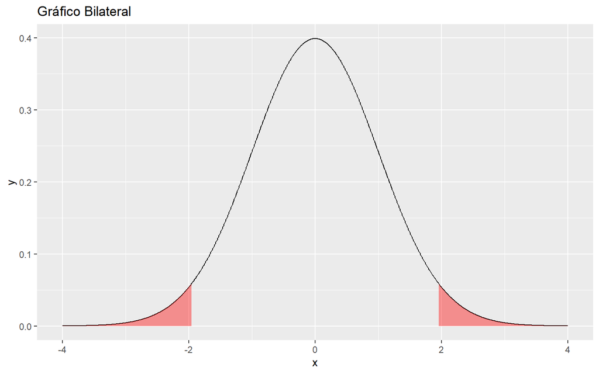

```r
# Bibliotecas necesarias
library(ggplot2)
# Gráfico Bilateral
mu <- 0
sigma <- 1
alpha <- 0.05
x <- seq(-4, 4, by=0.01)
y <- dnorm(x, mean=mu, sd=sigma)
lower_tail <- qnorm(alpha/2)
upper_tail <- qnorm(1 - alpha/2)

ggplot(data.frame(x,y), aes(x, y)) +
  geom_line() +
  geom_area(data=data.frame(x=x[x<=lower_tail], y=y[x<=lower_tail]), fill="red", alpha=0.4) +
  geom_area(data=data.frame(x=x[x>=upper_tail], y=y[x>=upper_tail]), fill="red", alpha=0.4) +
  ggtitle('Gráfico Bilateral')
```

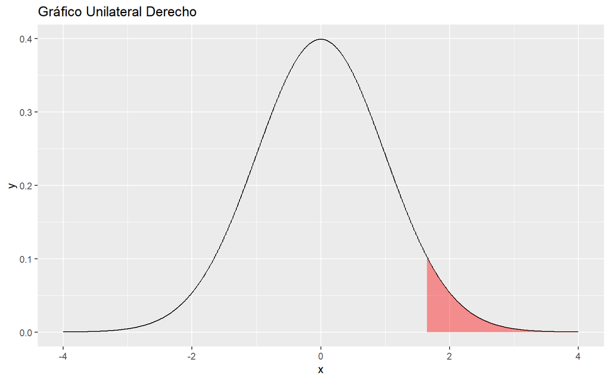

```r
# Gráfico Unilateral Derecho
upper_tail_right <- qnorm(1 - alpha)
ggplot(data.frame(x,y), aes(x, y)) +
  geom_line() +
  geom_area(data=data.frame(x=x[x>=upper_tail_right], y=y[x>=upper_tail_right]), fill="red", alpha=0.4) +
  ggtitle('Gráfico Unilateral Derecho')
```

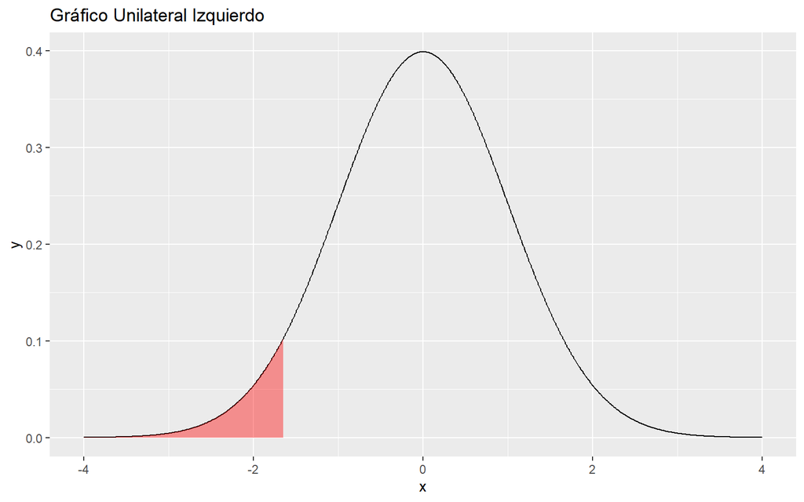

```r
# Gráfico Unilateral Izquierdo
lower_tail_left <- qnorm(alpha)
ggplot(data.frame(x,y), aes(x, y)) +
  geom_line() +
  geom_area(data=data.frame(x=x[x<=lower_tail_left], y=y[x<=lower_tail_left]), fill="red", alpha=0.4) +
  ggtitle('Gráfico Unilateral Izquierdo')
```